# Приоритизация гипотез по увеличению выручки интернет-магазина и анализ результатов проведённого A/B-теста

# Содержание

Вместе с отделом маркетинга крупного интернет-магазина подготовлен список гипотез для увеличения выручки.

**Требуется:**

1. Приоритизировать гипотезы в списке.
2. Запустить A/B-тест и проанализировать его результаты.

**Данные хранятся в следующих файлах:**

- В файле `hypothesis.csv` перечислены характеристики 9 гипотез по увеличению выручки интернет-магазина.
- Результаты проведённого A/B-теста описаны в файлах `orders.csv` и `visitors.csv`.

## Импорт библиотек и определение функций проекта

### Импорт библиотек

```python
import os
import pandas as pd
import numpy as np
import matplotlib.pyplot as plt
import datetime as dt
from scipy import stats as st
import seaborn as sns
```

### Функции загрузки и обзора данных

```python
# определение функции обзора данных
# ===============================================
# на вход подаётся датафрейм df
# на выходе:
#     - 10 случайных строк df
#     - информация df.info()
#     - количество явных дубликатов в строках df
#     - процент пропусков данных в столбцах df
# ===============================================
def data_observe(df):
    row_num = 5    # количество отображаемых строк таблицы

    print('Произвольные строки таблицы:')
    print('============================')
    if len(df) >= row_num:
        display(df.sample(row_num))
    else:
        display(df)

    print('\nИнформация о таблице:')
    print('=====================')
    df.info()

    print('\nКоличество явных дубликатов в таблице:')
    print('======================================')
    print(df.duplicated().sum())

    print('\nПроцент пропусков в столбцах:')
    print('=============================')
    display(pd.DataFrame(
                round((df.isna().mean()*100),2), columns=['NaNs, %'])
                .sort_values(by='NaNs, %', ascending=False
            )
        .style.format('{:.2f}')
        .background_gradient('coolwarm')
    )
```

```python
# определение кроссплатформенной функции загрузки данных
# ======================================================
# на вход подаётся:
#     file_name - имя файла
# на выходе - датафрейм с загруженными данными
# ======================================================
def open_file(file_name, sep=','):
    pth1 = '/datasets/' + file_name             # яндексовский путь
    pth2 = os.path.join('datasets', file_name)  # мой путь

    if os.path.exists(pth1):
        return pd.read_csv(pth1, sep=sep)
    elif os.path.exists(pth2):
        return pd.read_csv(pth2, sep=sep)
    else:
        print("ERROR: Neither Yandex nor local path is reacable...")

    return pd.DataFrame() # в случае ошибки чтения вернём пустой DataFrame
```

### Функция расчёта кумулятивных метрик

```python
# определение кроссплатформенной функции расчёта
# кумулятивных метрик А/В-теста
# =========================================================
# на вход подаются:
#     orders - информация о заказах
#     visitors - информация о посетителях интернет-магазина
# на выходе - датафрейм с посчитанными метриками:
#     кумулятивный средний чек по группам тестирования
#     кумулятивная конверсия по группам тестирования
# =========================================================
def get_cummulative_data(orders, visitors):
    # выделим массив уникальных пар значений дат и групп для последующей
    # индексации при подсчёте кумулятивной выручки
    dates_and_groups = orders[['date', 'group']].drop_duplicates()

    # агрегируем значения с накоплением
    orders_agg = (
        dates_and_groups
        .apply(
            # для каждой строки dates_and_groups агрегируем orders по условию
            lambda x : orders[np.logical_and(
                orders['date'] <= x['date'],
                orders['group'] == x['group']
            )]
            .agg(
                {
                    'date' : 'max',
                    'group': 'max',
                    'transaction_id' : 'nunique',
                    'visitor_id' : 'nunique',
                    'revenue' : 'sum'
                }
            ),
            axis=1
        )
        .sort_values(by=['date', 'group'])
    )

    # переименуем колонки
    orders_agg.columns = ['date', 'group', 'num_orders',
                          'num_buyers', 'revenue']

    # агрегируем количество посетителей с накоплением
    visitors_agg = (
        dates_and_groups
        .apply(
            # для каждой строки dates_and_groups агрегируем orders по условию
            lambda x : visitors[np.logical_and(
                visitors['date'] <= x['date'],
                visitors['group'] == x['group']
            )]
            .agg(
                {
                    'date' : 'max',
                    'group': 'max',
                    'visitors' : 'sum'
                }
            ),
            axis=1
        )
        .sort_values(by=['date', 'group'])
    )

    # переименуем колонки
    visitors_agg.columns = ['date', 'group', 'num_visitors']

    # объединяем с orders_agg
    cummulative_data = orders_agg.merge(
        visitors_agg, left_on=['date', 'group'], right_on=['date', 'group']
    )

    # вычисляем сумулятивную конверсию по группам
    cummulative_data['conversion'] = (
        cummulative_data['num_buyers'] / cummulative_data['num_visitors']
    )

    return cummulative_data
```

## Приоритизация гипотез по увеличению выручки

На первом этапе необходимо расставить приоритеты для 9 гипотез по увеличению выручки интернет-магазина.

### Обзор данных

Откроем и изучим файл `hypothesis.csv`, в котором перечислены характеристики 9 гипотез по увеличению выручки:

```python
hypothesis = open_file('hypothesis.csv', sep=',')
if not hypothesis.empty:
    data_observe(hypothesis)
```

```
Произвольные строки таблицы:
============================
```

|  | Hypothesis | Reach | Impact | Confidence | Efforts |
| --- | --- | --- | --- | --- | --- |
| 5 | Добавить страницу отзывов клиентов о магазине,... | 3 | 2 | 2 | 3 |
| 1 | Запустить собственную службу доставки, что сок... | 2 | 5 | 4 | 10 |
| 8 | Запустить акцию, дающую скидку на товар в день... | 1 | 9 | 9 | 5 |
| 7 | Добавить форму подписки на все основные страни... | 10 | 7 | 8 | 5 |
| 2 | Добавить блоки рекомендаций товаров на сайт ин... | 8 | 3 | 7 | 3 |

```
Информация о таблице:
=====================
<class 'pandas.core.frame.DataFrame'>
RangeIndex: 9 entries, 0 to 8
Data columns (total 5 columns):
 #   Column      Non-Null Count  Dtype
---  ------      --------------  -----
 0   Hypothesis  9 non-null      object
 1   Reach       9 non-null      int64
 2   Impact      9 non-null      int64
 3   Confidence  9 non-null      int64
 4   Efforts     9 non-null      int64
dtypes: int64(4), object(1)
memory usage: 488.0+ bytes

Количество явных дубликатов в таблице:
======================================
0

Процент пропусков в столбцах:
=============================
```

|  | NaNs, % |
| --- | --- |
| Hypothesis | 0.00 |
| Reach | 0.00 |
| Impact | 0.00 |
| Confidence | 0.00 |
| Efforts | 0.00 |

Таблица `hypothesis` состоит из 9 строк, 5 столбцов. Типы данных в столбцах - object, int64.

Согласно описанию данных, столбцы хранят следующую информацию:

- `Hypothesis` — краткое описание гипотезы;
- `Reach` — охват пользователей по 10-балльной шкале;
- `Impact` — влияние на пользователей по 10-балльной шкале;
- `Confidence` — уверенность в гипотезе по 10-балльной шкале;
- `Efforts` — затраты ресурсов на проверку гипотезы по 10-балльной шкале. Чем больше значение `Efforts`, тем дороже проверка гипотезы.

Столбцы поименованы в смешаном стиле - целесообразно привести названия к нижнему регистру.

Для оценок, хранимых в столбцах `Reach`, `Impact`, `Confidence`, `Efforts` тип int64, очевидно, избыточен. Тем не менее, ввиду малого размера таблицы не будем менять тип столбцов для экономии памяти.

В таблице отсутствуют явные дубликаты и пропуски данных.

### Предварительная обработка

По результатам обзора данных таблицы `hypothesis` приведём названия столбцов к нижнему регистру:

```python
hypothesis.columns = hypothesis.columns.str.lower()
hypothesis.columns
```

```
Index(['hypothesis', 'reach', 'impact', 'confidence', 'efforts'], dtype='object')
```

Столбцы поименованы в хорошем стиле.

### Приоритизация гипотез

Таблица `hypothesis` содержит данные об охвате пользователей, влиянии на них, уверенности в гипотезе и затратах ресурсов на её проверку. Воспользуемся фреймворками `ICE` и `RICE` для расстановки приоритетов.

#### Приоритизация с помошью фреймворка ICE

Посчитаем оценку гипотез в рамках фреймворка `ICE` по следубщей формуле:

$$ ICE = \frac{Impact \times Confidence}{Efforts}. $$

```python
# посчитаем метрику ice
hypothesis['ice'] = (
    round(
        hypothesis['impact'] * hypothesis['confidence'] / hypothesis['efforts'],
        1
    )
)
# ранжируем гипотезы
pd.options.display.max_colwidth = 150
hypothesis[['hypothesis','ice']].sort_values(by='ice', ascending=False)
```

|  | hypothesis | ice |
| --- | --- | --- |
| 8 | Запустить акцию, дающую скидку на товар в день рождения | 16.2 |
| 0 | Добавить два новых канала привлечения трафика, что позволит привлекать на 30% больше пользователей | 13.3 |
| 7 | Добавить форму подписки на все основные страницы, чтобы собрать базу клиентов для email-рассылок | 11.2 |
| 6 | Показать на главной странице баннеры с актуальными акциями и распродажами, чтобы увеличить конверсию | 8.0 |
| 2 | Добавить блоки рекомендаций товаров на сайт интернет магазина, чтобы повысить конверсию и средний чек заказа | 7.0 |
| 1 | Запустить собственную службу доставки, что сократит срок доставки заказов | 2.0 |
| 5 | Добавить страницу отзывов клиентов о магазине, что позволит увеличить количество заказов | 1.3 |
| 3 | Изменить структура категорий, что увеличит конверсию, т.к. пользователи быстрее найдут нужный товар | 1.1 |
| 4 | Изменить цвет фона главной страницы, чтобы увеличить вовлеченность пользователей | 1.0 |

В рамках фреймворка `ICE` наиболее перспективными с точки зрения увеличения выручки представляются гипотезы (в порядке убывания приоритета):

1. Запустить акцию, дающую скидку на товар в день рождения
1. Добавить два новых канала привлечения трафика, что позволит привлекать на 30% больше пользователей
1. Добавить форму подписки на все основные страницы, чтобы собрать базу клиентов для email-рассылок
1. Показать на главной странице баннеры с актуальными акциями и распродажами, чтобы увеличить конверсию
1. Добавить блоки рекомендаций товаров на сайт интернет магазина, чтобы повысить конверсию и средний чек заказа

Остальные гипотезы получили ранг, более чем в 3 раза меньший по сравнению с перечисленными.

Учтём при расчёте приоритетов параметр охвата пользователей `Reach`.

#### Приоритизация с помошью фреймворка RICE

Рассчитаем оценку гипотез в рамках фреймворка `RICE` по следубщей формуле:

$$ RICE = \frac{Reach \times Impact \times Confidence}{Efforts}. $$

```python
# посчитаем метрику rice
hypothesis['rice'] = (
    round(
        hypothesis['reach'] * hypothesis['impact'] * hypothesis['confidence'] /
        hypothesis['efforts'],
        1
    )
)

# ранжируем гипотезы
pd.options.display.max_colwidth = 150
hypothesis[['hypothesis','ice','rice']].sort_values(by='rice', ascending=False)
```

|  | hypothesis | ice | rice |
| --- | --- | --- | --- |
| 7 | Добавить форму подписки на все основные страницы, чтобы собрать базу клиентов для email-рассылок | 11.2 | 112.0 |
| 2 | Добавить блоки рекомендаций товаров на сайт интернет магазина, чтобы повысить конверсию и средний чек заказа | 7.0 | 56.0 |
| 0 | Добавить два новых канала привлечения трафика, что позволит привлекать на 30% больше пользователей | 13.3 | 40.0 |
| 6 | Показать на главной странице баннеры с актуальными акциями и распродажами, чтобы увеличить конверсию | 8.0 | 40.0 |
| 8 | Запустить акцию, дающую скидку на товар в день рождения | 16.2 | 16.2 |
| 3 | Изменить структура категорий, что увеличит конверсию, т.к. пользователи быстрее найдут нужный товар | 1.1 | 9.0 |
| 1 | Запустить собственную службу доставки, что сократит срок доставки заказов | 2.0 | 4.0 |
| 5 | Добавить страницу отзывов клиентов о магазине, что позволит увеличить количество заказов | 1.3 | 4.0 |
| 4 | Изменить цвет фона главной страницы, чтобы увеличить вовлеченность пользователей | 1.0 | 3.0 |

С учётом охвата пользователей ситуация изменилась:

1. Ярким лидером стала занимавшая в оценке `ICE` 3-ю позицию гипотеза "Добавить форму подписки на все основные страницы, чтобы собрать базу клиентов для email-рассылок" (лидирует с 2-кратным перевесом относительно 2 позиции)
1. На втроре место поднялась замыкавшая top-5 по версии `ICE` гипотеза "Добавить блоки рекомендаций товаров на сайт интернет магазина, чтобы повысить конверсию и средний чек заказа"
1. Гипотезы "Добавить два новых канала привлечения трафика, что позволит привлекать на 30% больше пользователей" и "Показать на главной странице баннеры с актуальными акциями и распродажами, чтобы увеличить конверсию" по-прежнему занимают средние строчки top-5
1. Замыкает top-5 по версии `RICE` прошлый лидер - гипотеза "Запустить акцию, дающую скидку на товар в день рождения" (очевидно, из-за низкого мгновенного охвата пользователей, родившихся в конкретный день)
1. Прочие гипотезы имеют низкий приоритет в рамках обоих фреймворков

Отобразим приоритеты на точечной диаграмме:

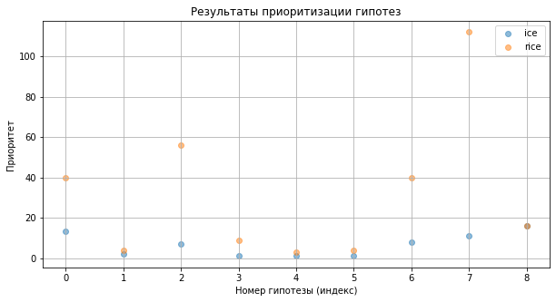

```python
# отобразим распределение в виде точечной диаграммы
x_values = hypothesis.index # порядковые номера (замена id)
plt.figure(figsize=(10, 5))
plt.scatter(x_values, hypothesis['ice'], label='ice', alpha=.5)
plt.scatter(x_values, hypothesis['rice'], label='rice', alpha=.5)
plt.title('Результаты приоритизации гипотез')
plt.xlabel('Номер гипотезы (индекс)')
plt.ylabel('Приоритет')
plt.grid()
plt.legend()
plt.show()
```

### Выводы

По итогу приоритизации бизнес-гипотез по увеличению выручки интернет-магазина можно заключить:

1. Состав top-5 гипотез в рамках фреймворков `ICE` и `RICE` совпадает.
1. Введение в рассмотрение охвата пользователей существенно перераспределяет приоритеты.
1. В рамках фреймворка `ICE` сложнее определить, с какой именно гипотезы начать проверку - первые три гипотезы имеют близкие приоритеты.
1. Фреймворк `RICE` исправляет эту ситуацию, выделив ярко лидирующую гипотезу под номером 7.
1. Проверку представляется целесообразным начинать с гипотезы **"Добавить форму подписки на все основные страницы, чтобы собрать базу клиентов для email-рассылок".**

## Анализ результатов A/B-теста

Теперь необходимо проанализировать результаты проведённого A/B-теста гипотезы "Добавить форму подписки на все основные страницы, чтобы собрать базу клиентов для email-рассылок", описанные в файлах `orders.csv` и `visitors.csv`, содержащих данные о заказах и количестве посетителей интернет-магазина пользователями.

Основные статистические гипотезы, которые проверялись в ходе теста:

1. О различии конверсии пользователей групп А и В (статистическая гипотеза H0 - конверсии групп А и В одинаковы).
2. О различии среднего чека пользователей групп А и В (статистическая гипотеза H0 - средние чеки групп А и В одинаковы).

Начнём с изучения данных.

### Обзор данных

Откроем и изучим файл `orders.csv`:

```python
orders = open_file('orders.csv', sep=',')
if not orders.empty:
    data_observe(orders)
```

```
Произвольные строки таблицы:
============================
```

|  | transactionId | visitorId | date | revenue | group |
| --- | --- | --- | --- | --- | --- |
| 487 | 2786000406 | 2744017357 | 2019-08-19 | 1490 | A |
| 848 | 1063646926 | 102981183 | 2019-08-05 | 14489 | B |
| 846 | 4256972642 | 3281496343 | 2019-08-05 | 1990 | A |
| 455 | 2781850870 | 2954449915 | 2019-08-06 | 3070 | B |
| 730 | 3335803766 | 477780734 | 2019-08-30 | 7300 | A |

```
Информация о таблице:
=====================
<class 'pandas.core.frame.DataFrame'>
RangeIndex: 1197 entries, 0 to 1196
Data columns (total 5 columns):
 #   Column         Non-Null Count  Dtype
---  ------         --------------  -----
 0   transactionId  1197 non-null   int64
 1   visitorId      1197 non-null   int64
 2   date           1197 non-null   object
 3   revenue        1197 non-null   int64
 4   group          1197 non-null   object
dtypes: int64(3), object(2)
memory usage: 46.9+ KB

Количество явных дубликатов в таблице:
======================================
0

Процент пропусков в столбцах:
=============================
```

|  | NaNs, % |
| --- | --- |
| transactionId | 0.00 |
| visitorId | 0.00 |
| date | 0.00 |
| revenue | 0.00 |
| group | 0.00 |

Таблица `orders` состоит из 1197 строк, 5 столбцов. Типы данных в столбцах - object, int64.

Согласно описанию данных, столбцы хранят следующую информацию:

- `transactionId` — идентификатор заказа;
- `visitorId` — идентификатор пользователя, совершившего заказ;
- `date` — дата, когда был совершён заказ;
- `revenue` — выручка заказа;
- `group` — группа A/B-теста, в которую попал заказ.

Столбцы поименованы в смешаном стиле - целесообразно привести названия к стилю "snake_case".

Для значений, хранимых в столбцах `transactionId`, `visitorId`, `revenue` тип int64, очевидно, достаточен.

На этапе предварительной обработки целесообразно достоверно обеспечить формат даты в столбце `date` путём преобразования типов.

В таблице отсутствуют явные дубликаты и пропуски данных.

Откроем и изучим файл `visitors.csv`:

```python
visitors = open_file('visitors.csv', sep=',')
if not visitors.empty:
    data_observe(visitors)
```

```
Произвольные строки таблицы:
============================
```

|  | date | group | visitors |
| --- | --- | --- | --- |
| 19 | 2019-08-20 | A | 575 |
| 58 | 2019-08-28 | B | 654 |
| 46 | 2019-08-16 | B | 413 |
| 24 | 2019-08-25 | A | 621 |
| 22 | 2019-08-23 | A | 468 |

```
Информация о таблице:
=====================
<class 'pandas.core.frame.DataFrame'>
RangeIndex: 62 entries, 0 to 61
Data columns (total 3 columns):
 #   Column    Non-Null Count  Dtype
---  ------    --------------  -----
 0   date      62 non-null     object
 1   group     62 non-null     object
 2   visitors  62 non-null     int64
dtypes: int64(1), object(2)
memory usage: 1.6+ KB

Количество явных дубликатов в таблице:
======================================
0

Процент пропусков в столбцах:
=============================
```

|  | NaNs, % |
| --- | --- |
| date | 0.00 |
| group | 0.00 |
| visitors | 0.00 |

Таблица `visitors` состоит из 62 строк, 3 столбцов. Типы данных в столбцах - object, int64.

Согласно описанию данных, столбцы хранят следующую информацию:

- `date` — дата;
- `group` — группа A/B-теста;
- `visitors` — количество пользователей в указанную дату в указанной группе A/B-теста.

Столбцы поименованы в хорошем стиле.

Для значений, хранимых в столбце `visitors` тип int64, очевидно, избыточен. Тем не менее, ввиду малого размера таблицы не будем менять тип столбца для экономии памяти.

На этапе предварительной обработки целесообразно достоверно обеспечить формат даты в столбце `date` путём преобразования типов.

В таблице отсутствуют явные дубликаты и пропуски данных.

### Предварительная обработка данных проведённого А/В-теста

По результатам обзора данных таблицы `orders` приведём названия столбцов к стилю "snake_case":

```python
orders.rename(
    columns={'transactionId' : 'transaction_id',
             'visitorId' : 'visitor_id'},
    inplace=True
)
orders.columns
```

```
Index(['transaction_id', 'visitor_id', 'date', 'revenue', 'group'], dtype='object')
```

Столбцы поименованы в хорошем стиле.

Обеспечим формат даты в соответствующих столбцах таблиц `orders` и `visitors`:

```python
orders['date'] = orders['date'].map(
    lambda x: dt.datetime.strptime(x, '%Y-%m-%d')
)
visitors['date'] = visitors['date'].map(
    lambda x: dt.datetime.strptime(x, '%Y-%m-%d')
)
```

Предварительная обработка завершена.

### Исследование аномалий данных A/B-теста

Прежде чем проверять и интерпретировать результаты проведённого A/B-теста выясним, не закрались ли ошибки в итоговые данные. Обзор данных показал, что явные дубликаты и пропуски отсутствуют, однако *возможны* следующие проблемы в данных:

1. Для одинаковых уникальных комбинаций даты и группы в таблице `visitors` указаны различные значения количества посетителей.
2. Для одинаковых уникальных комбинаций `transaction_id`, `visitor_id`, `date` и `group` в таблице `orders` указаны различные значения `revenue`.
3. Одни и те же пользователи попали в обе группы теста.

Проверим данные на наличие этих проблем:

```python
# 1 проблема
(
    visitors.groupby(by=['date', 'group'])
    .agg({'visitors':'count'}) # считаем количество visitors в группировке
    .reset_index()
    .query('visitors > 1')
    .shape[0] # считаем количество строк
)
```

```
0
```

```python
# 2 проблема
(
    orders.groupby(by=['transaction_id', 'visitor_id', 'date', 'group'])
    .agg({'revenue':'count'}) # считаем количество revenue в группировке
    .reset_index()
    .query('revenue > 1')
    .shape[0] # считаем количество строк
)
```

```
0
```

Первая и вторая потенциальные проблемы в данных не обнаружены.

Проверим наличие пользователей, попавших в обе группы:

```python
# 3 проблема
group_a_users = list(orders.query('group == "A"')['visitor_id'].unique())
group_b_users = list(orders.query('group == "B"')['visitor_id'].unique())

intersection = []
for user in group_a_users:
    if user in group_b_users:
        intersection.append(user)
# вывод результата
print(f'{len(intersection)} пользователей попали в обе группы:')
print(
    round(len(intersection) * 100 / len(group_a_users), 2),
    '% от объёма группы А'
)
print(
    round(len(intersection) * 100 / len(group_b_users), 2),
    '% от объёма группы B'
)
```

```
58 пользователей попали в обе группы:
11.53 % от объёма группы А
9.9 % от объёма группы B
```

Действительно, 58 посетителей интернет-магазина по какой-то причине попали в обе группы теста. Данные по ним могут исказить результат A/B-теста, поэтому представляется целесообразным удалить их из таблицы `orders`:

```python
orders = orders.query('visitor_id not in @intersection')
```

Перейдём к проверке результатов A/B-теста.

### Определение динамики кумулятивной выручки по группам

Проследим динамику кумулятивной выручки по группам за период тестирования. Данная метрика напрямую связана с целевой метрикой "размер среднего чека".

Для нахождения кумулятивной выручки просумминуем на каждую дату теста выручку по группам за текущую и предыдущие даты.

Определим и визуализируем кумулятивную выручку по группам теста:

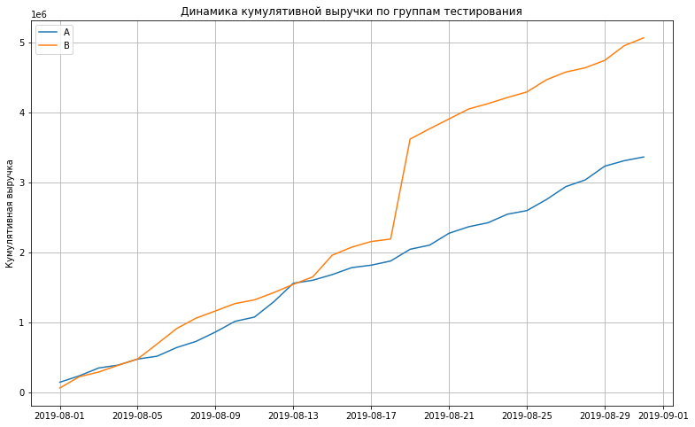

```python
# агрегируем значения с накоплением и посчитаем кумулятивные метрики
cummulative_data = get_cummulative_data(orders, visitors)

# построим графики кумулятивной выручки по группам тестирования
plt.figure(figsize=(13, 8))
# для группы А
plt.plot(
    cummulative_data.query('group == "A"')['date'],
    cummulative_data.query('group == "A"')['revenue'],
    label='A'
)
# для группы B
plt.plot(
    cummulative_data.query('group == "B"')['date'],
    cummulative_data.query('group == "B"')['revenue'],
    label='B'
)
plt.legend()
plt.title('Динамика кумулятивной выручки по группам тестирования')
plt.ylabel('Кумулятивная выручка')
plt.grid()
plt.show()
```

В течение первых 5 дней теста выручка групп практически не отличалась. Затем с 6 по 12 августа выручка группы В стабильно превышала группу А. 13 августа значения метрики у групп сравнялись, а в дальнейшем выручка группы В стабильно превышает группу А.

Отметим, что в периоды 12-13 и 18-19 августа наблюдаются скачки метрики для групп А и В соответственно. Это может свидетельствовать об аномальных покупках (с высокой выручкой) в эти дни.

### Определение динамики кумулятивного среднего чека по группам

Посчитаем целевую метрику теста - размер кумулятивного среднего чека по группам. Для этого разделим кумулятивную выручку на агрегированное количество заказов на каждую дату.

Визуализируем динамику кумулятивного среднего чека по группам теста:

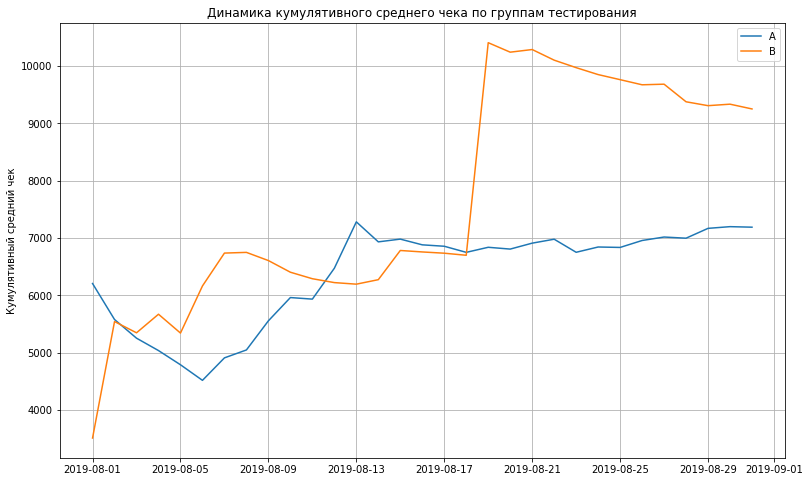

```python
# построим графики кумулятивного среднего чека по группам тестирования
plt.figure(figsize=(13, 8))
# для группы А
plt.plot(
    cummulative_data.query('group == "A"')['date'],
    cummulative_data.query('group == "A"')['revenue'] /
    cummulative_data.query('group == "A"')['num_orders'],
    label='A'
)
# для группы B
plt.plot(
    cummulative_data.query('group == "B"')['date'],
    cummulative_data.query('group == "B"')['revenue'] /
    cummulative_data.query('group == "B"')['num_orders'],
    label='B'
)
plt.legend()
plt.title('Динамика кумулятивного среднего чека по группам тестирования')
plt.ylabel('Кумулятивный средний чек')
plt.grid()
plt.show()
```

Как видно из графика, кумулятивный средний чек контрольной группы А после падения в начале тестирования растёт, начиная с 7 августа, до отметки 7000, возле которой колеблется с 13 августа и до окончания тестирования.

Средний чек в группе В с самого начала бурно растёт, затем слегка снижается, колеблется в районе 6800-6900 (около установившегося среднего чека группы А).

Затем, 19 августа, наблюдается резкий скачкообразный рост среднего чека группы В до значения более чем 10000, после чего средний чек группы В до конца среза данных плавно снижался в направлении установившегося значения группы А.

Это подтверждает наши предположения о наличии 19 августа одного или более заказов с аномально высокой выручкой.

### Определение динамики относительного изменения кумулятивного среднего чека группы B к группе A

Посмотрим на отношение кумулятивного среднего чека группы B к группе A в динамике по ходу тестирования. Для этого разделим кумулятивный средний чек группы В на кумулятивный средний чек группы А:

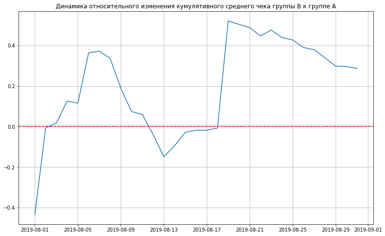

```python
# собираем данные по группам в один датафрейм
total_cumulative_revenue = (
    cummulative_data.query('group == "A"')
    .merge(
        cummulative_data.query('group == "B"'),
        left_on='date',
        right_on='date',
        how='left',
        suffixes=['_a', '_b']
    )
)

# строим график отношения средних чеков
plt.figure(figsize=(13, 8))

plt.plot(
    total_cumulative_revenue['date'],
    (total_cumulative_revenue['revenue_b'] / total_cumulative_revenue['num_orders_b']) /
    (total_cumulative_revenue['revenue_a'] / total_cumulative_revenue['num_orders_a']) - 1
    # вычитаем 1, чтобы получить превышение / занижение
)
plt.title('Динамика относительного изменения кумулятивного среднего чека группы B к группе A')
plt.grid()
plt.axhline(y=0, color='red', linestyle='--')
plt.show()
```

На рисунке красным пунктиром отмечена условная граница кумулятивного среднего чека контрольной группы А. График отражает динамику относительного превышения среднего чека группы В над средним чеком группы А.

Можно видеть, что в первый день теста группа В показала себя на примерно 40% хуже группы А. Затем к концу первой недели уверенно обгоняла контрольную группу. Затем всю вторую неделю превышение среднего чека группы В снижалось, и к 13 августа она проигрывала контрольной группе 15%. Вероятно, это связано с наличием в этот период аномальных покупок в группе А, или опережающей конверсией в ней и увеличением количества заказов.

С 13 по 18 день теста средний чек группы В стабилизируется и приближается к группе А.

19 августа в группе В происходит резкий скачок, отмеченный нами ранее, после чего превышение среднего чека начинает стабилизацию в направлении границы группв А.

Вероятно, 19 августа имели место один или несколько очень дорогих заказов в группе В.

### Определение динамики кумулятивной конверсии по группам

Конверсией будем считать превращение посетителей в уникальных покупателей. Кумулятивные метрики, в том числе и конверсию, мы рассчитали ранее.

Визуализируем динамику кумулятивной конверсии по группам тестирования:

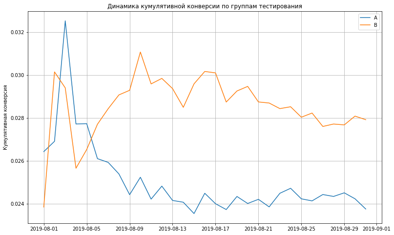

```python
# построим графики кумулятивной выручки по группам тестирования
plt.figure(figsize=(13, 8))
# для группы А
plt.plot(
    cummulative_data.query('group == "A"')['date'],
    cummulative_data.query('group == "A"')['conversion'],
    label='A'
)
# для группы B
plt.plot(
    cummulative_data.query('group == "B"')['date'],
    cummulative_data.query('group == "B"')['conversion'],
    label='B'
)
plt.legend()
plt.title('Динамика кумулятивной конверсии по группам тестирования')
plt.ylabel('Кумулятивная конверсия')
plt.grid()
plt.show()
```

В начале теста кумулятивная конверсия группы В растёт в среднем медленнее, чем в контрольной группе А. При этом 5-6 августа конверсии обеих групп примерно сравниваются, после чего наблюдается достаточно резкий рост кумулятивной конверсии группы В на фоне постепенного спада и стабилизации конверсии группы А.

Кумулятивная конверсия контрольной группы А к концу 2 недели теста стабилизируется на уровне 2.4%.

Конверсия в группе В в течение второй и третьей недель теста переживает скачкообразные колебания в районе отметки 3%, после чего к концу среза тестирования наблюдаются признаки её стабилизации в районе 2.8%.

Предварительно можно заключить, что конверсия группы В по результатам теста превышает конверсию группы А.

### Определение динамики относительного изменения кумулятивной конверсии группы B к группе A

Аналогично среднему чеку, определим и визуализируем динамику относительного изменения кумулятивной конверсии группы B к группе A:

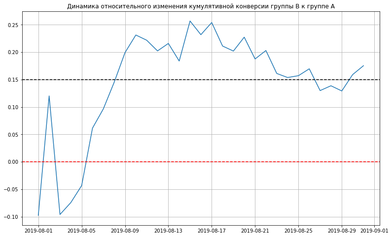

```python
# собираем данные по группам в один датафрейм
cumulative_conversion = (
    cummulative_data.query('group == "A"')
    .merge(
        cummulative_data.query('group == "B"'),
        left_on='date',
        right_on='date',
        how='left',
        suffixes=['_a', '_b']
    )
)

# строим график отношения средних чеков
plt.figure(figsize=(13, 8))

plt.plot(
    cumulative_conversion['date'],
    (cumulative_conversion['conversion_b'] / cumulative_conversion['conversion_a']) - 1
    # вычитаем 1, чтобы получить превышение / занижение
)
plt.title('Динамика относительного изменения кумулятивной конверсии группы B к группе A')
plt.grid()
plt.axhline(y=0, color='red', linestyle='--')
plt.axhline(y=.15, color='black', linestyle='--')
plt.show()
```

Динамика относительного изменения конверсии группы В к группе А подтверждает сделанные выше выводы:

- в первую неделю тестирования, не считая однодневного выброса, конверсия группы В ниже группы А на 5-10%;
- начиная с 6 августа, конверсия группы В стабильно превышает конверсию группы А;
- при этом к концу второй недели она пытается закрепиться на уровне 20%, на третьей неделе увеличивается до 25% и начинает плавно снижаться;
- на четвёртой неделе тестирования превышение конверсии группы В над конверсией группы А стабилизируется на уровне 15%.

*Вывод: кумулятивная конверсия тестовой группы превышает конверсию контрольной в среднем на 15%.*

### Определение статистических выбросов в A/B-тесте

Выше мы определили, что на имеющемся срезе данных А/В-теста средний чек и конверсия для тестовой группы В превышают значения этих метрик для контрольной группы. Вместе с тем, была зафиксирована возможность наличия аномальных покупок.

Определим статистические выбросы в результатах теста. Рассмотрим, как распределено количество заказов для уникальных покупателей:

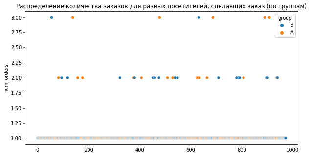

```
Перцентили 90, 95, 99: [1. 1. 2.]
```

```python
# посчитаем количество заказов для каждого покупателя
orders_by_visitors = (
    orders
    .groupby(by='visitor_id', as_index=False)
    .agg({'transaction_id':'nunique',
          'group':'max'})
)
orders_by_visitors.columns = ['visitor_id', 'num_orders', 'group']

# отобразим распределение в виде точечной диаграммы
plt.figure(figsize=(10, 5))

x_values = orders_by_visitors.index
plt.title('Распределение количества заказов для разных посетителей, сделавших заказ (по группам)')
sns.scatterplot(
    x=x_values,
    y='num_orders',
    hue="group",
    data=orders_by_visitors
)
plt.show()

# выведем перцентили 90, 95, 99
print('Перцентили 90, 95, 99:', np.percentile(orders_by_visitors['num_orders'], [90, 95, 99]))
```

Очевидно, даже 2 заказа - достаточно редкое событие в данном тесте. будем учитывать это при оценке статистической значимости полученных результатов. А именно - будем считать выбросами 2 заказа и более.

Рассмотрим, как распределена стоимость заказов:

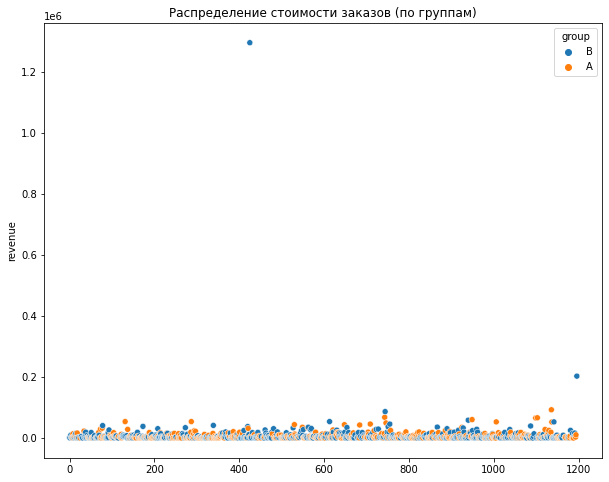

```
Перцентили 90, 95, 99: [17990. 26785. 53904.]
```

```python
# отобразим распределение в виде точечной диаграммы
plt.figure(figsize=(10, 8))
x_values = orders.index
plt.title('Распределение стоимости заказов (по группам)')
sns.scatterplot(
    x=x_values,
    y='revenue',
    hue="group",
    data=orders
)
plt.show()

# выведем перцентили 90, 95, 99
print('Перцентили 90, 95, 99:', np.percentile(orders['revenue'], [90, 95, 99]))
```

А вот и аномальные заказы в группе В - на 200000 и на 1.2 млн. При этом 95% заказов были сделаны на сумму до 27000, а 99% - на сумму до 54000. Будем считать выбросами заказы на сумму 27000 и более и проверим повлияет ли их исключение на статистическую значимость результатов теста.

### Определение статистической значимости различий в конверсии между группами по «сырым» данным

Для начала определим статистическую значимость различий в конверсии между группами по исходным, "сырым" данным. Для этого воспользуемся непараметрическим статистическим тестом Манна-Уитни.

Напомним, проверяется статистическая гипотеза о равенстве конверсии между группами.

```python
# рассчитаем статистическую значимость различий в конверсии
print(
    'raw conversion p-value:',
    '{0:.9f}'
    .format(
        st.mannwhitneyu(cummulative_data.query('group == "A"')['conversion'],
                        cummulative_data.query('group == "B"')['conversion'])[1]
    )
)
```

```
raw conversion p-value: 0.000000012
```

Напомним, что мы проверяем гипотезу о различии конверсии пользователей групп А и В:

- статистическая гипотеза H0 - конверсии групп А и В одинаковы;
- альтернатива H1 - конверсии групп А и В не одинаковы.

Очевидно, полученное значение p-value заведомо меньше любого разумного уровня статистической значимости, и нам следует отвергнуть гипотезу о равенстве конверсий в группах.

Поскольку ранее мы выяснили, что **конверсия целевой группы В установилась на уровне, на 15% превышающем конверсию группы А, то можно утверждать, что это статистически обоснованный результат**.

### Определение статистической значимости различий в среднем чеке заказа между группами по «сырым» данным

Другой метрикой, которую мы оценивали в тесте, является значение среднего чека. Для начала определим статистическую значимость различий в чеке между группами по исходным, "сырым" данным. Для этого воспользуемся непараметрическим статистическим тестом Манна-Уитни.

Напомним, проверяется статистическая гипотеза о равенстве средних чеков между группами.

```python
# рассчитаем статистическую значимость различий в чеках
print(
    'raw orders mean check p-value:',
    '{0:.3f}'
    .format(
        st.mannwhitneyu(orders.query('group == "A"')['revenue'],
                        orders.query('group == "B"')['revenue'])[1]
    )
)
```

```
raw orders mean check p-value: 0.829
```

При таком уровне статистической значимости мы не можем отвергнуть нулевую гипотезу о равенстве средних чеков. Возможно, велико влияние выбросов. Очистим данные и повторно оценим статистическую значимость.

### Определение статистической значимости различий в конверсии между группами по «очищенным» данным

Очистим данные от выбросов - удалим пользователей, сделавших 2 и более заказов, а также тех, кто заказывал на сумму 27000 и более:

```python
# выделим идентификаторы анормальных пользователей
abnormal_visitors = pd.concat(
    [
        # аномальные конверсии
        orders_by_visitors.query('num_orders >= 2')['visitor_id'],
        # аномальные суммы заказов
        orders.query('revenue >= 27000')['visitor_id']
    ],
    axis=0
).drop_duplicates().sort_values()

# выведем количество аномальных покупателей
abnormal_visitors.shape[0]
```

```
86
```

Итак, в разряд аномальных покупателей попали 86 человек.

```python
# выведем количество заказов в "сырых" данных
print(orders.shape[0])

clean_orders = orders.query('visitor_id not in @abnormal_visitors')

# выведем количество заказов в очищенных данных
print(clean_orders.shape[0])
```

```
1016
887
```

После очистки количество заказов сократилось с 1016 до 887. Проверим, как очистка повлияла на уровни статистической значимости:

```python
# агрегируем значения с накоплением и посчитаем кумулятивные метрики
# для "чистых" данных
clean_cummulative_data = get_cummulative_data(clean_orders, visitors)

# рассчитаем статистическую значимость различий в конверсии
print(
    'clean conversion p-value:',
    '{0:.10f}'
    .format(
        st.mannwhitneyu(clean_cummulative_data.query('group == "A"')['conversion'],
                        clean_cummulative_data.query('group == "B"')['conversion'])[1]
    )
)
```

```
clean conversion p-value: 0.0000000004
```

Вероятность признать конверсии одинаковыми еще более сократилась!

### Определение статистической значимости различий в среднем чеке заказа между группами по «очищенным» данным

Определим статистическую значимость различий в чеке между группами по очищенным данным:

```python
# рассчитаем статистическую значимость различий в чеке
print(
    'clean orders mean check p-value:',
    '{0:.3f}'
    .format(
        st.mannwhitneyu(clean_orders.query('group == "A"')['revenue'],
                        clean_orders.query('group == "B"')['revenue'])[1]
    )
)
```

```
clean orders mean check p-value: 0.727
```

Вероятность, с которой можно считать чеки групп А и В одинаковым, сократилась с 82.9% до 72.7%. Однако при таком уровне статистической значимости мы по-прежнему не можем считать чеки групп А и В различными.

### Решение по результатам теста

Основной целью гипотезы, проверяемой с помощью А/В-теста, являлось увеличение выручки. В ходе анализа среза результатов мы выяснили что:

1. С достаточным уровнем статистической значимости установившаяся конверсия в группе В превышает установившуюся конверсию в группе А на 15%.
1. Средний чек в группе В к концу рассматриваемого среза теста превышает средний чек в группе А на порядка 30%.
1. Однако графики демонстрируют продолжающуюся тенденцию к снижению как непосредственно среднего чека в группе В, так и его превышения по отношению к установившемуся на уровне 7000 среднему чеку группы А.
1. Оцененный уровень статистической значимости не позволяет считать средние чеки групп А и В различными.

**В этих условиях представляется целесообразным продолжить тест еще по крайней мере на 1 неделю.**

## Общий вывод

В рамках проведённого исследования мы:

- приоритизировали и выбрали наиболее приоритетную гипотезу для А/В-теста;
- провели А/В-тест и проанализировали его результаты.
1. С учётом охвата пользователей (фреймворк `RICE`) наиболее приоритетной призана следующая гипотеза о путях увеличения выручки интернет-магазина: **"Добавить форму подписки на все основные страницы, чтобы собрать базу клиентов для email-рассылок"**.
1. Проведённый А/В-тест гипотезы показал:
   1. С достаточным уровнем статистической значимости установившаяся конверсия в группе В превышает установившуюся конверсию в группе А на 15%.
   2. Средний чек в группе В к концу рассматриваемого среза теста превышает средний чек в группе А на 30%.
   3. Однако графики демонстрируют продолжающуюся тенденцию к снижению как непосредственно среднего чека в группе В, так и его превышения по отношению к установившемуся на уровне 7000 среднему чеку группы А.
   4. Оцененный уровень статистической значимости не позволяет считать средние чеки групп А и В различными.
1. **В этих условиях представляется целесообразным продолжить А/В-тест еще по крайней мере на 1 неделю.**